# Chap11_1

J.H AHN

2021 12 17

## 11.1 Hierarchical and grouped time series

### Hierarchical time series

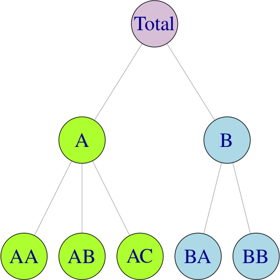

Fig 11.1

이런 작은 계층에서 $n=1+2+5=8$로 가장 마지막 레벨(가장 바닥)의 수 $m=5$이다.  
모든 계층 구조에서 $n>m$이다!

$t$시점에서 가장 바닥의 관찰 값은 계층의 나머지의 합과 같다.  
예를 들어

$$\begin{equation}
y_{t}=y_{AA,t}+y_{AB,t}+y_{AC,t}+y_{BA,t}+y_{BB,t},
\tag{11.1}
\end{equation}$$

$$\begin{equation}
y{A,t}=y_{AA,t}+y_{AB,t}+y_{AC,t}\qquad \text{and} \qquad y_{B,t}=y_{BA,t}+y_{BB,t}.
\tag{11.2}
\end{equation}$$

### Example: Australian tourism hierarchy

호주는 6개 주와 2개 준주로 나뉘며 각 주마다 자체 정부와 경제 및 행정 자치권이 있다.  
편의상 주와 지역을 모두 “주”라고 합니다.  
이러한 각 상태는 Fig 11.2 및 Table 11.1 과 같이 영역으로 더 세분화될 수 있다.  
총 76개의 그러한 지역이 있다.  
사업 계획가와 관광 당국은 호주 전체, 각 주와 테리토리, 지역에 대한 예측에 관심이 있다.

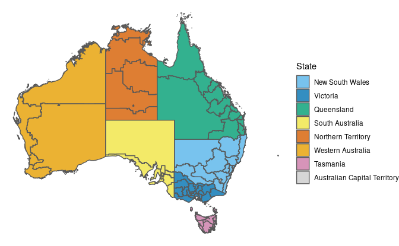

Fig 11.2

[output not shown]

tourism(tsibble 형식 data) 하룻밤의 수는 호주인 가정에서 멀리 보내고 여행으로 측정 분기 국내 관광 수요에 대한 데이터를 포함하고 있다.

```r
tourism
```

```
## # A tsibble: 24,320 x 5 [1Q]
## # Key:       Region, State, Purpose [304]
##    Quarter Region   State           Purpose  Trips
##      <qtr> <chr>    <chr>           <chr>    <dbl>
##  1 1998 Q1 Adelaide South Australia Business  135.
##  2 1998 Q2 Adelaide South Australia Business  110.
##  3 1998 Q3 Adelaide South Australia Business  166.
##  4 1998 Q4 Adelaide South Australia Business  127.
##  5 1999 Q1 Adelaide South Australia Business  137.
##  6 1999 Q2 Adelaide South Australia Business  200.
##  7 1999 Q3 Adelaide South Australia Business  169.
##  8 1999 Q4 Adelaide South Australia Business  134.
##  9 2000 Q1 Adelaide South Australia Business  154.
## 10 2000 Q2 Adelaide South Australia Business  169.
## # ... with 24,310 more rows
```

주요 변수 State및 Region지리적 영역을 나타내는 반면 추가 키 Purpose는 여행 목적을 설명한다.  
지금은 여행의 목적을 무시하고 지리적 계층 구조만 고려할 것이다.  
그래프와 표를 더 간단하게 만들기 State위해 약어를 사용하도록 다시 코딩한다.

```r
library(tsibble)

tourism <-
    tourism %>%
    mutate(State = recode(State,
                          `New South Wales` = "NSW",
                          `Northern Territory` = "NT",
                          `Queensland` = "QLD",
                          `South Australia` = "SA",
                          `Tasmania` = "TAS",
                          `Victoria` = "VIC",
                          `Western Australia` = "WA"
    ))

tourism
```

```
## # A tsibble: 24,320 x 5 [1Q]
## # Key:       Region, State, Purpose [304]
##    Quarter Region   State Purpose  Trips
##      <qtr> <chr>    <chr> <chr>    <dbl>
##  1 1998 Q1 Adelaide SA    Business  135.
##  2 1998 Q2 Adelaide SA    Business  110.
##  3 1998 Q3 Adelaide SA    Business  166.
##  4 1998 Q4 Adelaide SA    Business  127.
##  5 1999 Q1 Adelaide SA    Business  137.
##  6 1999 Q2 Adelaide SA    Business  200.
##  7 1999 Q3 Adelaide SA    Business  169.
##  8 1999 Q4 Adelaide SA    Business  134.
##  9 2000 Q1 Adelaide SA    Business  154.
## 10 2000 Q2 Adelaide SA    Business  169.
## # ... with 24,310 more rows
```

`fabletools::aggregate_key()`함수를 이용하여 계층 구조의 최하위 수준에 있는 지역을 기준으로 여행(overnight trips) 수를 집계하는 시계열을 만들 수 있으며, 필요하다면 주별 집계, 전국 총계도 나타낼 수 있다.

계층적 시계열 구조는 `aggregate_key()`함수 내에서 `parent/child`관계로 정의해 줄 수 있다.

```r
tourism_hts <-
    tourism %>%
    aggregate_key(State / Region, Trips = sum(Trips))

tourism_hts
```

```
## # A tsibble: 6,800 x 4 [1Q]
## # Key:       State, Region [85]
##    Quarter State        Region        Trips
##      <qtr> <chr*>       <chr*>        <dbl>
##  1 1998 Q1 <aggregated> <aggregated> 23182.
##  2 1998 Q2 <aggregated> <aggregated> 20323.
##  3 1998 Q3 <aggregated> <aggregated> 19827.
##  4 1998 Q4 <aggregated> <aggregated> 20830.
##  5 1999 Q1 <aggregated> <aggregated> 22087.
##  6 1999 Q2 <aggregated> <aggregated> 21458.
##  7 1999 Q3 <aggregated> <aggregated> 19914.
##  8 1999 Q4 <aggregated> <aggregated> 20028.
##  9 2000 Q1 <aggregated> <aggregated> 22339.
## 10 2000 Q2 <aggregated> <aggregated> 19941.
## # ... with 6,790 more rows
```

`aggregate_key()`만 했을 경우에는 parent/child관계로 묶은 모든 집합에 대한 데이터가 기록이 됨. 즉 계층별 모든 데이터가 들어가있음. parent/child 관계에 묶이지 않은 나머지 데이터는 나타나지 않음. (위의 예에서는 Purpose가 없어짐)

이렇게 만들어진 tsibble에는 각 분기의 주별 여행 수를 보여준다.  
데이터를 시각화해보면 2010년 이후 ACT, New South Wales, Queensland, South Australia 및 Victoria와 같은 일부 주에서 눈에 띄는 성장이 있었다는 것과 2014년에는 서호주에 상당한 도약이 있었다는 것을 확인할 수 있다.

반면 `fabletools::is_aggregated()`함수를 쓰면 Region을 묶어 주게 됨. 위에서 ’aggregate_key()`함수만 사용했을 때는 각 region별 데이터가 있었지만,`is_aggregate()`함수로 Region을 기준으로 묶어주면 각 Region별 데이터가 없어지고 Region이 묶인 데이터만 남음.

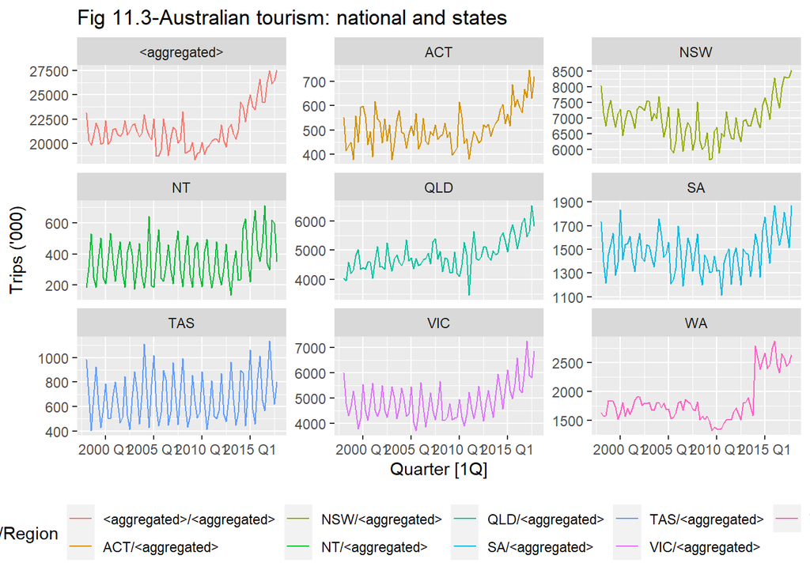

```r
tourism_hts %>%
    filter(is_aggregated(Region)) %>%
    autoplot(Trips) +
    facet_wrap(vars(State), scales = "free_y", ncol = 3) +
    labs(title = "Fig 11.3-Australian tourism: national and states",
         y = "Trips ('000)") +
    theme(legend.position = "bottom")
```

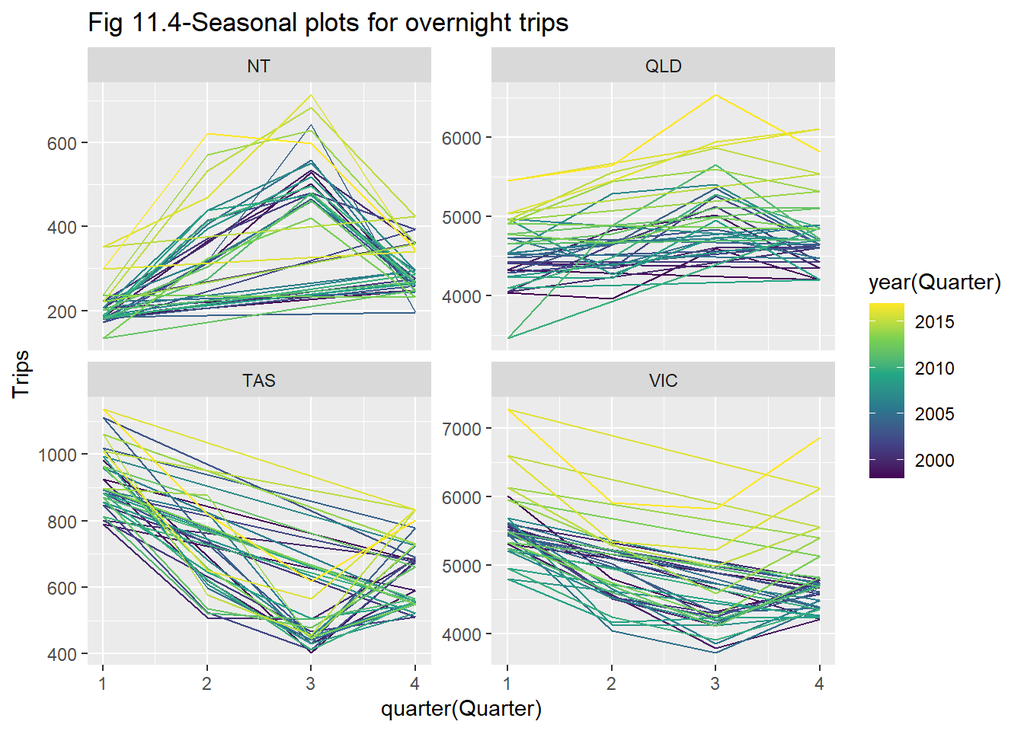

```r
tourism_hts %>%
    filter(State == "QLD" | State == "NT" | State == "VIC" | State == "TAS") %>%
    filter(is_aggregated(Region)) %>%
    group_by(yearquarter(Quarter), State) %>%
    mutate(Trips = sum(Trips)) %>%
    ungroup() %>%
    ggplot(aes(quarter(Quarter), Trips, color = year(Quarter))) +
    geom_path() +
    facet_wrap(vars(factor(State)), scales = "free_y", ncol = 2) +
    labs(title = "Fig 11.4-Seasonal plots for overnight trips") +
    scale_color_viridis_c()
```

퀸즐랜드(QLD) 및 노던 테리토리(NT)와 같은 북부 주의 계절 패턴은 열대 기후와 비가 오는 여름 개월로 인해 겨울(Q3에 해당)에 방문이 가장 많다.  
대조적으로, 남부 주들은 여름에 최고조에 달하는 경향이 있다(Q1에 해당).  
이것은 Fig 11.4 에서 퀸즐랜드와 노던 테리토리(위쪽 열에 표시)와 빅토리아(VIC)와 태즈메이니아(TAS,최남단 주)(아래쪽 열에 표시)에 대한 계절 플롯에서 확인할 수 있다.

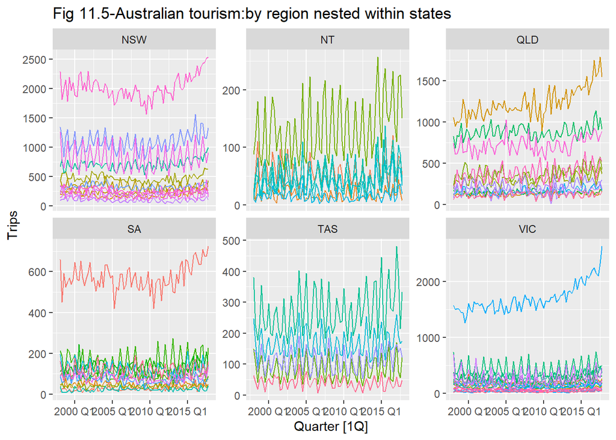

```r
tourism_hts %>%
    filter(State == "NSW" | State == "SA" | State == "QLD" |
               State == "NT" | State == "VIC" | State == "TAS") %>%
    filter(!is_aggregated(Region)) %>%
    autoplot(Trips) +
    facet_wrap(vars(State), scales = "free_y", ncol = 3) +
    labs(title = "Fig 11.5-Australian tourism:by region nested within states") +
    theme(legend.position = "none")
```

Fig 11.5 의 plot은 일부 선택된 지역에 대한 데이터를 보여줍니다.  
이를 통해 어떤 지역은 강한 경향이나 계절성을 보여주고, 어떤 지역은 대조적인 계절성을 보여주고, 어떤 지역은 그냥 노이즈로 보이는 각 주 내에서 다양한 지역 역학을 시각화하는 데 도움이 된다.

### Grouped time series

그룹화된 시계열은 데이터 구조가 고유한 계층적 방식으로는 자연스럽게 나눌 수 없다.  
Fig 11.6에 간단한 그룹화된 구조가 있다.  
가장 상단의 그룹을 Total이라 하고 가장 통합(aggregate)이 많이 된 수준의 값이다.  
이를 $y_t$라 하자.  
Total은 속성(A, B)로 나눠지고 이 계열을 $y_{A,t}$와 $y_{B,t}$로 한다.  
속성 (X,Y)로 나눠지는 계열은 $y_{X,t}$와 $y_{Y,t}$라 한다.  
가장 아래 수준에는 두 속성이 분해된 데이터가 있게 된다.

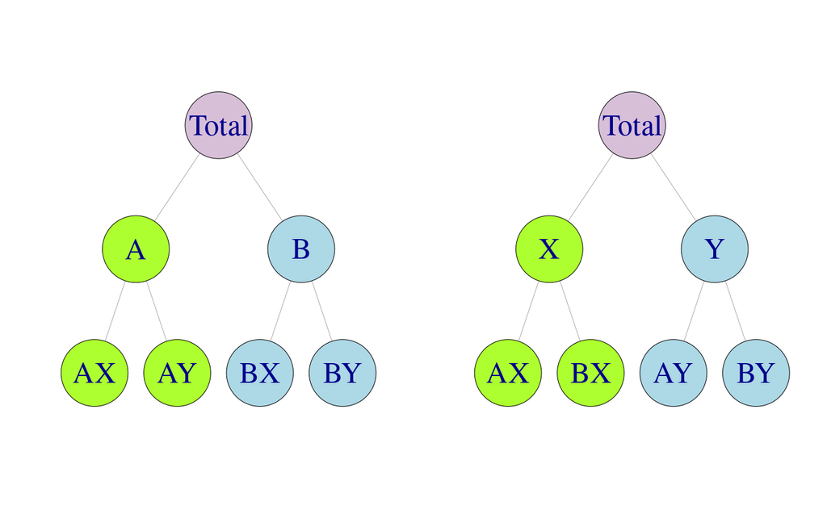

Fig 11.6

이 예시는 그룹화된 구조에서는 대안적인 통합 경로를 가질 수 있음을 보여준다.  
A,B로 각각 그룹화 할 수도 있고 X,Y로 각각 그룹화 할 수도 있다는 의미

$t$시점에서 계층구조는 아래와 같다.

$$\begin{equation*}
y_{t}=y_{AX,t}+y_{AY,t}+y_{BX,t}+y_{BY,t}.
\end{equation*}$$

그러나 그룹화된 구조의 첫 번째 수준은

$$\begin{equation} y_{A,t}=y_{AX,t}+y_{AY,t}\quad \quad y_{B,t}=y_{BX,t}+y_{BY,t}
\tag{11.3}
\end{equation}$$

가 될 수도 있고,

$$\begin{equation} y_{X,t}=y_{AX,t}+y{BX,t}\quad \quad y_{Y,t}=y_{AY,t}+y_{BY,t}
\tag{11.4}.
\end{equation}$$

가 될 수도 있다.

때로는 그룹화된 시계열은 그룹화할 수 있는 순서가 고유하지 않다는 의미에서 고유한 계층 구조를 부과하지 않는 계층적 시계열로 간주하기도 한다.

### Example: Australian prison population

이번 예시에서 호주 교도소 수감자수 데이터를 이용할 것이다.  
Fig 11.7의 상단 패널은 2005Q1-2016Q4 기간 동안 호주에 있는 총 수감자 수를 보여줍니다.  
상단 plot은 그룹화 구조의 최상위 계열을 나타낸다.

아래 패널은 (a)주 (b)법적 지위(피구금자가 이미 형을 선고받았거나 형을 기다리고 있는지 여부) 및 (c)성별에 따라 분류되거나 그룹화된 교도소 수감자수를 보여준다.  
세 가지 요소가 교차하지만 다른 요소 안에 내포된 요소는 없다.

```r
prison <-
    readr::read_csv("https://OTexts.com/fpp3/extrafiles/prison_population.csv") %>%
    mutate(Quarter = yearquarter(Date)) %>%
    select(-Date)  %>%
    as_tsibble(key = c(Gender, Legal, State, Indigenous),
               index = Quarter) %>%
    relocate(Quarter)
prison
```

```
## # A tsibble: 3,072 x 6 [1Q]
## # Key:       State, Gender, Legal, Indigenous [64]
##    Quarter State Gender Legal    Indigenous Count
##      <qtr> <chr> <chr>  <chr>    <chr>      <dbl>
##  1 2005 Q1 ACT   Female Remanded ATSI           0
##  2 2005 Q2 ACT   Female Remanded ATSI           1
##  3 2005 Q3 ACT   Female Remanded ATSI           0
##  4 2005 Q4 ACT   Female Remanded ATSI           0
##  5 2006 Q1 ACT   Female Remanded ATSI           1
##  6 2006 Q2 ACT   Female Remanded ATSI           1
##  7 2006 Q3 ACT   Female Remanded ATSI           1
##  8 2006 Q4 ACT   Female Remanded ATSI           0
##  9 2007 Q1 ACT   Female Remanded ATSI           0
## 10 2007 Q2 ACT   Female Remanded ATSI           1
## # ... with 3,062 more rows
```

`aggregate_key()`함수를 사용해서 시계열을 그룹화 할 수 있다.  
그룹화를 시킬 속성들은 `attribute1 * attribute2`와 같은 구문으로 쓸 수 있다.  
아래는 주(State), 성별(Gender), 법적지위(Legal)를 각각 그룹화하여 시계열을 만든 예이다.

```r
prison_gts <-
    prison %>% aggregate_key(State * Gender * Legal, Count = sum(Count) / 1e3)


prison_gts
```

```
## # A tsibble: 3,888 x 5 [1Q]
## # Key:       State, Gender, Legal [81]
##    Quarter State        Gender       Legal        Count
##      <qtr> <chr*>       <chr*>       <chr*>       <dbl>
##  1 2005 Q1 <aggregated> <aggregated> <aggregated>  24.3
##  2 2005 Q2 <aggregated> <aggregated> <aggregated>  24.6
##  3 2005 Q3 <aggregated> <aggregated> <aggregated>  24.5
##  4 2005 Q4 <aggregated> <aggregated> <aggregated>  24.4
##  5 2006 Q1 <aggregated> <aggregated> <aggregated>  24.5
##  6 2006 Q2 <aggregated> <aggregated> <aggregated>  25.0
##  7 2006 Q3 <aggregated> <aggregated> <aggregated>  25.4
##  8 2006 Q4 <aggregated> <aggregated> <aggregated>  25.9
##  9 2007 Q1 <aggregated> <aggregated> <aggregated>  25.9
## 10 2007 Q2 <aggregated> <aggregated> <aggregated>  26.5
## # ... with 3,878 more rows
```

```r
p01 <-
prison_gts %>%
    filter(is_aggregated(Gender), is_aggregated(State), is_aggregated(Legal)) %>%
    autoplot(Count) + labs(title = "Fig 11.7-Prison population: Total") +
    theme(legend.position = "none")
```

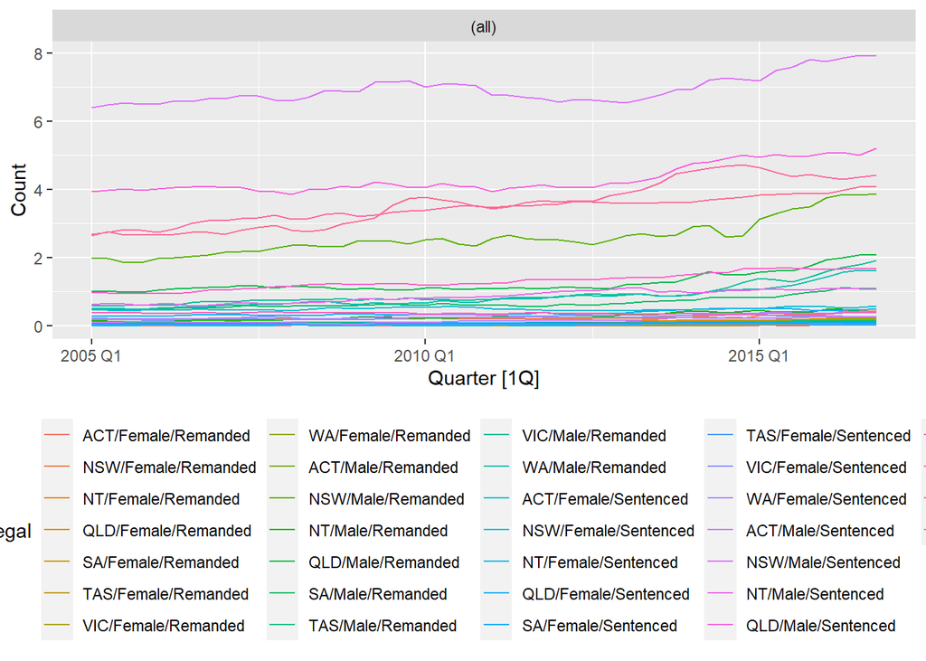

```r
prison_gts %>%
    filter(!is_aggregated(Gender), !is_aggregated(State), !is_aggregated(Legal)) %>%
    autoplot(Count) + facet_wrap(~ ., scales = "free_y") +
    theme(legend.position = "bottom")
```

```r
p02 <-
prison_gts %>%
    filter(!is_aggregated(Gender), is_aggregated(State), is_aggregated(Legal)) %>%
    autoplot(Count) + theme(legend.position = "none")
```

```r
p03 <-
prison_gts %>%
    filter(is_aggregated(Gender), is_aggregated(State), !is_aggregated(Legal)) %>%
    autoplot(Count) + theme(legend.position = "none")
```

```r
p04 <-
prison_gts %>%
    filter(is_aggregated(Gender), !is_aggregated(State), is_aggregated(Legal)) %>%
    autoplot(Count) + theme(legend.position = "none")
```

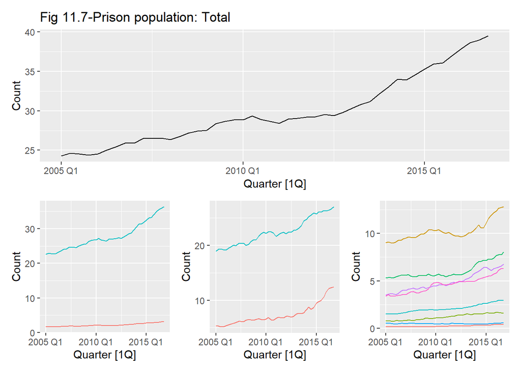

```r
library(patchwork)

p01 / (p02 + p03 + p04)
```

`is_aggregate()`함수를 `filter()`함수에 넣어 사용하면 원하는 그룹의 데이터를 찾는데 수월하다.  
예를 들어 전체 수감자 중 남성과 여성 수감자를 분리하여 보고 싶다면 아래 예시와 같이 성별(Gender)이 통합(aggregate)된 데이터는 빼고 나머지는 통합된 데이터만 가져오면 된다.

```r
p1 <-
prison_gts %>%
    filter(!is_aggregated(Gender), !is_aggregated(State), is_aggregated(Legal)) %>%
    autoplot(Count) +
    facet_wrap(~ State, scales = "free_y", nrow = 1) +
    labs(title = "Fig 11.8-Prision population State and gender") +
    theme(legend.position = "none")
```

```r
p2 <-
prison_gts %>%
    filter(is_aggregated(Gender), !is_aggregated(State), !is_aggregated(Legal)) %>%
    autoplot(Count) +
    facet_wrap(~ State, scales = "free_y", nrow = 1) +
    labs(title = "Fig 11.8-Prision population State and legal status") +
    theme(legend.position = "none")
```

```r
p3 <-
prison_gts %>%
    filter(!is_aggregated(Gender), is_aggregated(State), !is_aggregated(Legal)) %>%
    autoplot(Count) +
    facet_wrap(~ Gender, scales = "free_y", nrow = 1) +
    labs(title = "Fig 11.8-Prision population gender and legal status") +
    theme(legend.position = "none")
```

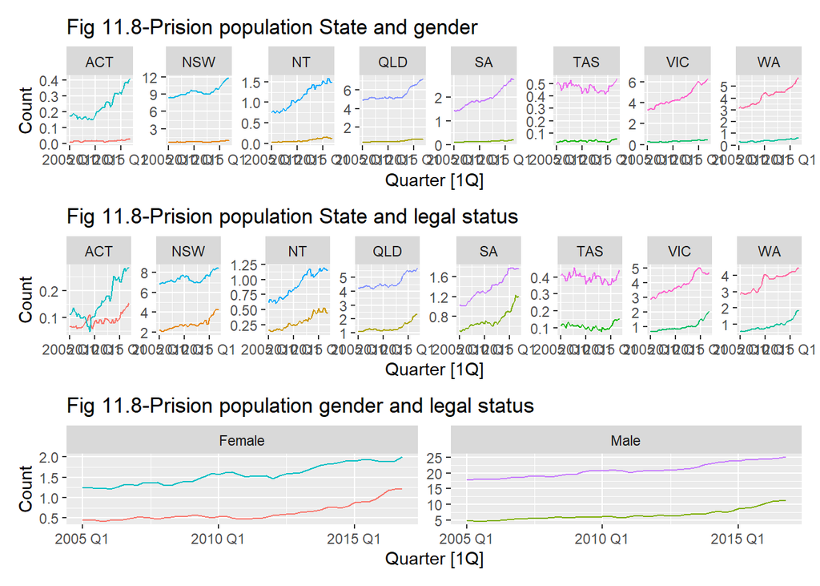

```r
p1 / p2 / p3
```

### Mixed hierarchical and grouped structure

종종 분해 요인은 중첩되기도 하고 교차되기도 한다.  
예를 들어, 호주 관광 데이터는 휴가, 비즈니스, 친구 및 친척 방문, 기타의 4가지 여행 목적으로 세분화할 수도 있다.  
이 그룹화 변수는 지리적 변수 내에 중첩되지 않는다.  
사실, 우리는 호주 전체, 각 주, 각 지역에 대한 여행 목적에 따라 밤샘 여행을 나눌 수 있다.  
우리는 그러한 구조를 여행 목적과 “교차”하는 “중첩된” 지리적 계층 구조로 설명한다.  
`aggregate_key()`를 사용하여 이런 중첩되기도 하고 계층을 가진 구조를 간단하게 나타낼 수 있다.

```r
tourism_full <-
    tourism %>%
    aggregate_key((State/Region) * Purpose, Trips = sum(Trips))

tourism_full
```

```
## # A tsibble: 34,000 x 5 [1Q]
## # Key:       State, Purpose, Region [425]
##    Quarter State        Purpose      Region        Trips
##      <qtr> <chr*>       <chr*>       <chr*>        <dbl>
##  1 1998 Q1 <aggregated> <aggregated> <aggregated> 23182.
##  2 1998 Q2 <aggregated> <aggregated> <aggregated> 20323.
##  3 1998 Q3 <aggregated> <aggregated> <aggregated> 19827.
##  4 1998 Q4 <aggregated> <aggregated> <aggregated> 20830.
##  5 1999 Q1 <aggregated> <aggregated> <aggregated> 22087.
##  6 1999 Q2 <aggregated> <aggregated> <aggregated> 21458.
##  7 1999 Q3 <aggregated> <aggregated> <aggregated> 19914.
##  8 1999 Q4 <aggregated> <aggregated> <aggregated> 20028.
##  9 2000 Q1 <aggregated> <aggregated> <aggregated> 22339.
## 10 2000 Q2 <aggregated> <aggregated> <aggregated> 19941.
## # ... with 33,990 more rows
```

`aggregate_key()`함수를 이용해서 State와 Region은 `parent/child`의 계층적 구조로 만든 후 이 계층과 Purpose를 각각의 그룹으로 나타내었다.

```r
tourism_full %>%
    filter(!is_aggregated(Region), !is_aggregated(Purpose))
```

```
## # A tsibble: 24,320 x 5 [1Q]
## # Key:       State, Purpose, Region [304]
##    Quarter State  Purpose  Region           Trips
##      <qtr> <chr*> <chr*>   <chr*>           <dbl>
##  1 1998 Q1 ACT    Business Canberra        150.
##  2 1998 Q1 ACT    Holiday  Canberra        196.
##  3 1998 Q1 ACT    Other    Canberra         21.7
##  4 1998 Q1 ACT    Visiting Canberra        183.
##  5 1998 Q1 NSW    Business Blue Mountains   18.8
##  6 1998 Q1 NSW    Holiday  Blue Mountains  104.
##  7 1998 Q1 NSW    Other    Blue Mountains    2.48
##  8 1998 Q1 NSW    Visiting Blue Mountains   70.5
##  9 1998 Q1 NSW    Business Capital Country  42.7
## 10 1998 Q1 NSW    Holiday  Capital Country  99.2
## # ... with 24,310 more rows
```

`aggregate_key()`적용 결과 통합하지 않은 데이터가 총 304종류

```r
tourism_full %>%
    filter(!is_aggregated(Region), is_aggregated(Purpose))
```

```
## # A tsibble: 6,080 x 5 [1Q]
## # Key:       State, Purpose, Region [76]
##    Quarter State  Purpose      Region                  Trips
##      <qtr> <chr*> <chr*>       <chr*>                  <dbl>
##  1 1998 Q1 ACT    <aggregated> Canberra                551.
##  2 1998 Q1 NSW    <aggregated> Blue Mountains          196.
##  3 1998 Q1 NSW    <aggregated> Capital Country         262.
##  4 1998 Q1 NSW    <aggregated> Central Coast           455.
##  5 1998 Q1 NSW    <aggregated> Central NSW             424.
##  6 1998 Q1 NSW    <aggregated> Hunter                  675.
##  7 1998 Q1 NSW    <aggregated> New England North West  330.
##  8 1998 Q1 NSW    <aggregated> North Coast NSW        1342.
##  9 1998 Q1 NSW    <aggregated> Outback NSW              96.6
## 10 1998 Q1 NSW    <aggregated> Riverina                215.
## # ... with 6,070 more rows
```

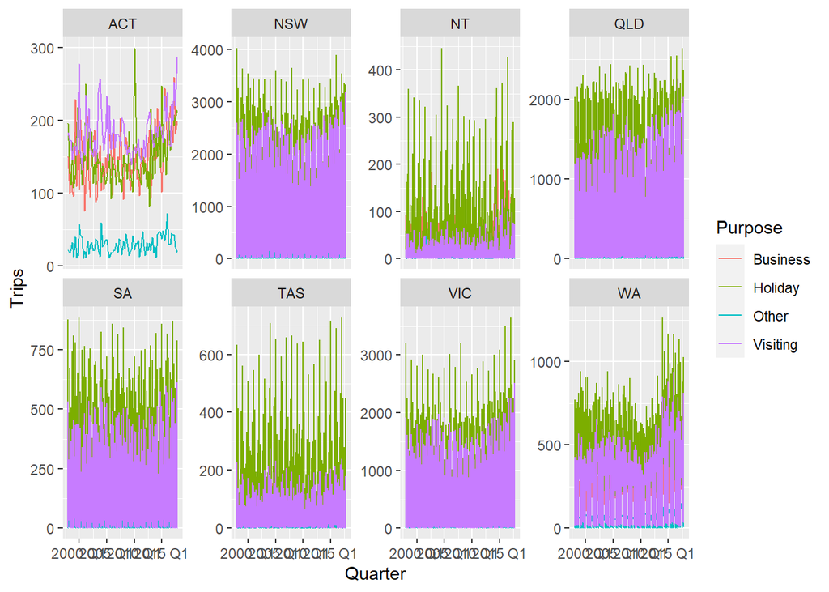

```r
tourism_full %>%
    filter(!is_aggregated(State), !is_aggregated(Purpose)) %>%
    ggplot(aes(Quarter, Trips, color = factor(Purpose))) +
    geom_line() +
    facet_wrap(vars(factor(State)), ncol = 4, scales = "free_y") +
    labs(color = "Purpose")
```

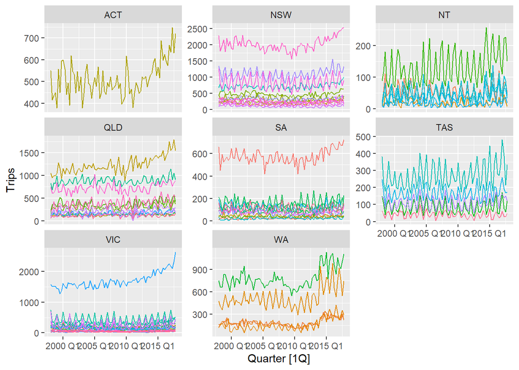

```r
tourism_full %>%
    filter(!is_aggregated(Region), is_aggregated(Purpose)) %>%
    autoplot(Trips) + facet_wrap(vars(State), scales = "free_y", ncol = 3) +
    theme(legend.position = "none")
```

지역별 계층구조로 만들어진(= 목적을 구분하지 않고 지역만으로 구분한) 데이터가 76종류

```r
tourism_full %>%
    filter(is_aggregated(Region), !is_aggregated(Purpose))
```

```
## # A tsibble: 2,880 x 5 [1Q]
## # Key:       State, Purpose, Region [36]
##    Quarter State        Purpose  Region        Trips
##      <qtr> <chr*>       <chr*>   <chr*>        <dbl>
##  1 1998 Q1 <aggregated> Business <aggregated>  3599.
##  2 1998 Q1 <aggregated> Holiday  <aggregated> 11806.
##  3 1998 Q1 <aggregated> Other    <aggregated>   680.
##  4 1998 Q1 <aggregated> Visiting <aggregated>  7098.
##  5 1998 Q2 <aggregated> Business <aggregated>  3724.
##  6 1998 Q2 <aggregated> Holiday  <aggregated>  9276.
##  7 1998 Q2 <aggregated> Other    <aggregated>   656.
##  8 1998 Q2 <aggregated> Visiting <aggregated>  6668.
##  9 1998 Q3 <aggregated> Business <aggregated>  4356.
## 10 1998 Q3 <aggregated> Holiday  <aggregated>  8642.
## # ... with 2,870 more rows
```

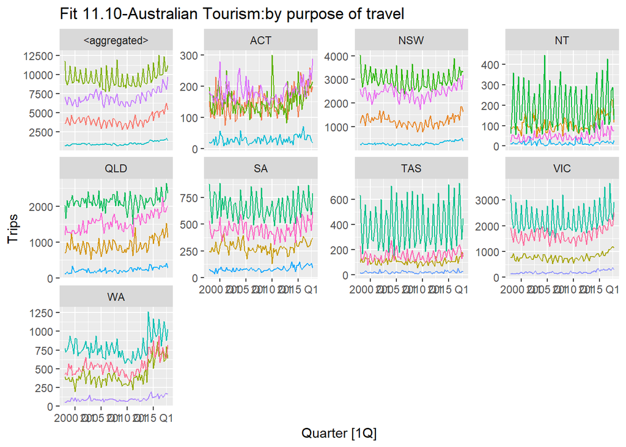

```r
tourism_full %>%
    filter(is_aggregated(Region), !is_aggregated(Purpose)) %>%
    autoplot(Trips) + facet_wrap(vars(State), scales = "free_y", ncol = 4) +
    labs(title = "Fit 11.10-Australian Tourism:by purpose of travel") +
    theme(legend.position = "none")
```

지역을 묶고 목적별로 나눈 데이터가 36종류

```r
tourism_full %>%
    filter(is_aggregated(Region), is_aggregated(Purpose))
```

```
## # A tsibble: 720 x 5 [1Q]
## # Key:       State, Purpose, Region [9]
##    Quarter State        Purpose      Region        Trips
##      <qtr> <chr*>       <chr*>       <chr*>        <dbl>
##  1 1998 Q1 <aggregated> <aggregated> <aggregated> 23182.
##  2 1998 Q2 <aggregated> <aggregated> <aggregated> 20323.
##  3 1998 Q3 <aggregated> <aggregated> <aggregated> 19827.
##  4 1998 Q4 <aggregated> <aggregated> <aggregated> 20830.
##  5 1999 Q1 <aggregated> <aggregated> <aggregated> 22087.
##  6 1999 Q2 <aggregated> <aggregated> <aggregated> 21458.
##  7 1999 Q3 <aggregated> <aggregated> <aggregated> 19914.
##  8 1999 Q4 <aggregated> <aggregated> <aggregated> 20028.
##  9 2000 Q1 <aggregated> <aggregated> <aggregated> 22339.
## 10 2000 Q2 <aggregated> <aggregated> <aggregated> 19941.
## # ... with 710 more rows
```